# HICP Forecasting for Norway (2010-2021)

#### Forecast Using MA

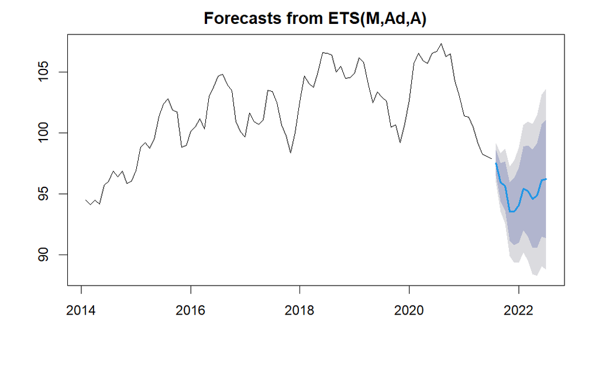

```r
forecast_ma3 <- forecast(MA3_hicp,12)
forecast_ma6 <- forecast(MA6_hicp,12)
forecast_ma9 <- forecast(MA9_hicp,12)
plot(forecast_ma3)
```

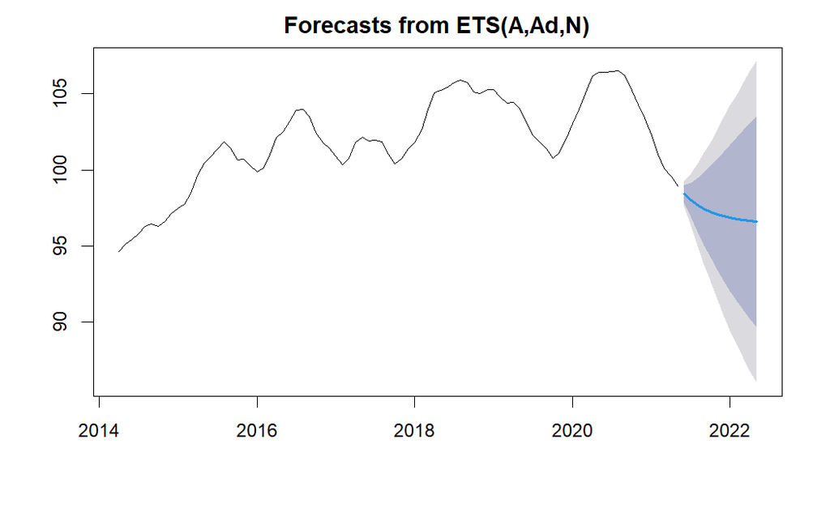

```r
plot(forecast_ma6)
```

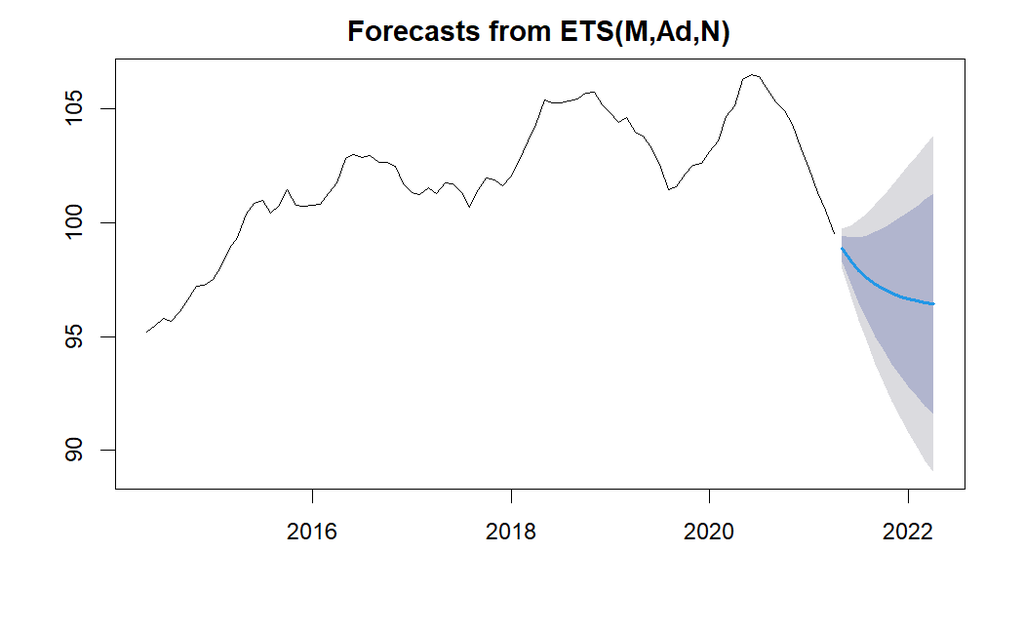

```r
plot(forecast_ma9)
```

```r
forecast_ma6$mean
```

```
          Jan      Feb      Mar      Apr      May      Jun      Jul      Aug      Sep
2021                                              98.42476 98.02426 97.70364 97.44696
2022 96.83985 96.75545 96.68788 96.63379 96.59049
          Oct      Nov      Dec
2021 97.24148 97.07697 96.94528
2022
```

We can see from the forecast that the Order 6 moving averages show similar ETS model of Additive error and additive Trend but the additive Seasonality seems to have been smoothened out by the moving averages and thus we dont see any seasonality factor here.

#### Residual Analysis for Simple Moving Averages

We consider the the model with an order of 6 for our forecast as it is a forecast for the next year.

Residual Plot and Histogram of Residuals :

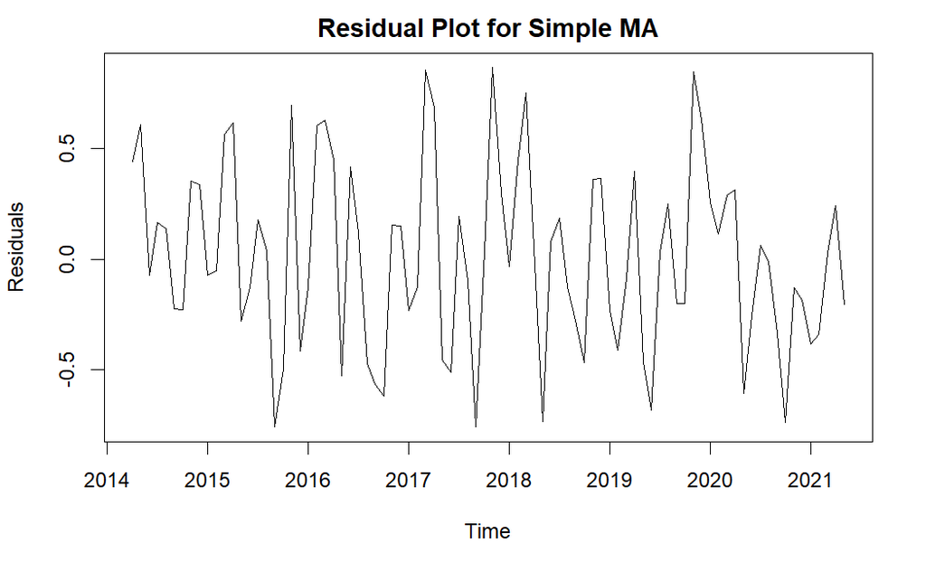

```r
plot(forecast_ma6$residuals,main="Residual Plot for Simple MA",ylab="Residuals")
```

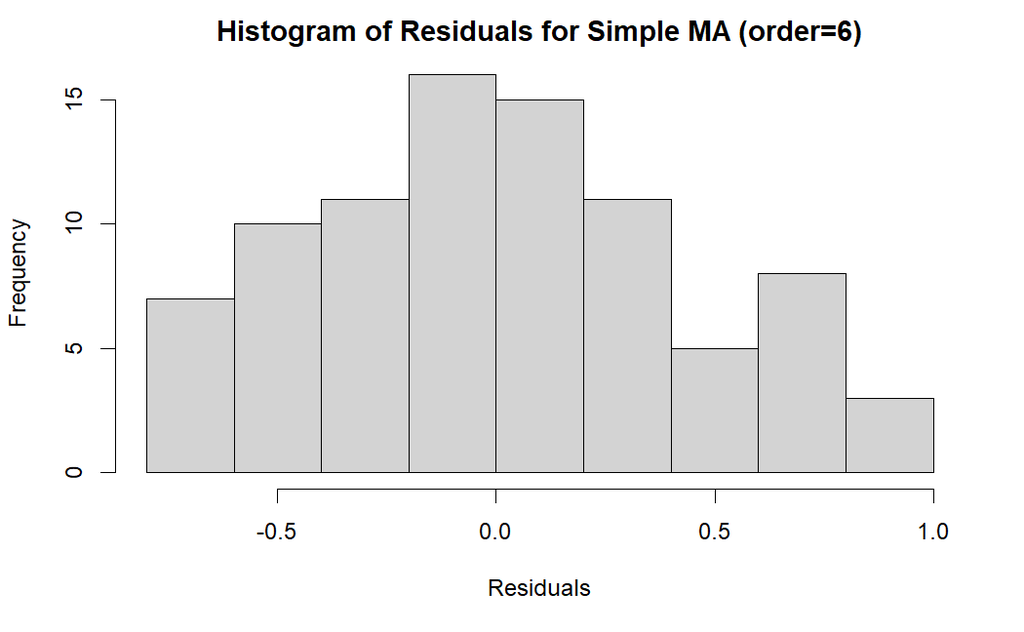

```r
hist(forecast_ma6$residuals,main="Histogram of Residuals for Simple MA (order=6)",xlab="Residuals")
```

We can see that the residuals are random in nature and are fairly normally distributed around 0 while being slightly skewed to right indicating there may be some underforecasting.

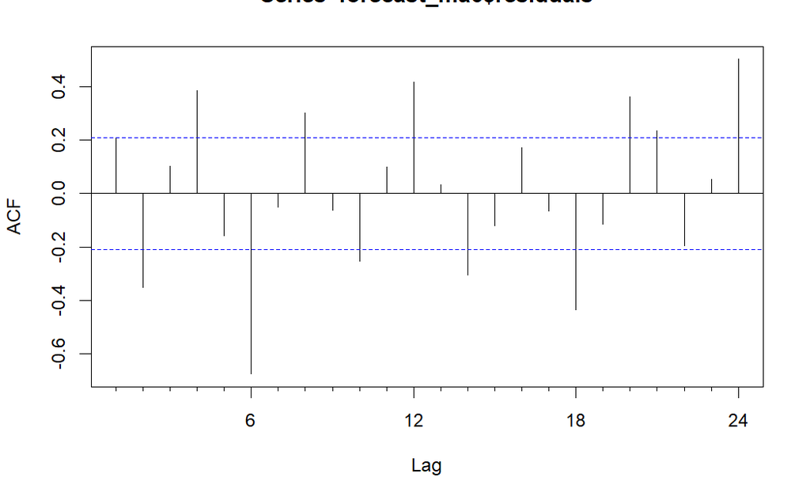

```r
Acf(forecast_ma6$residuals)
```

We can see that the ACF of residuals for moving averages are also not satisfactory due to significant lags at 6, 12 and 24.

Residual Vs Actual

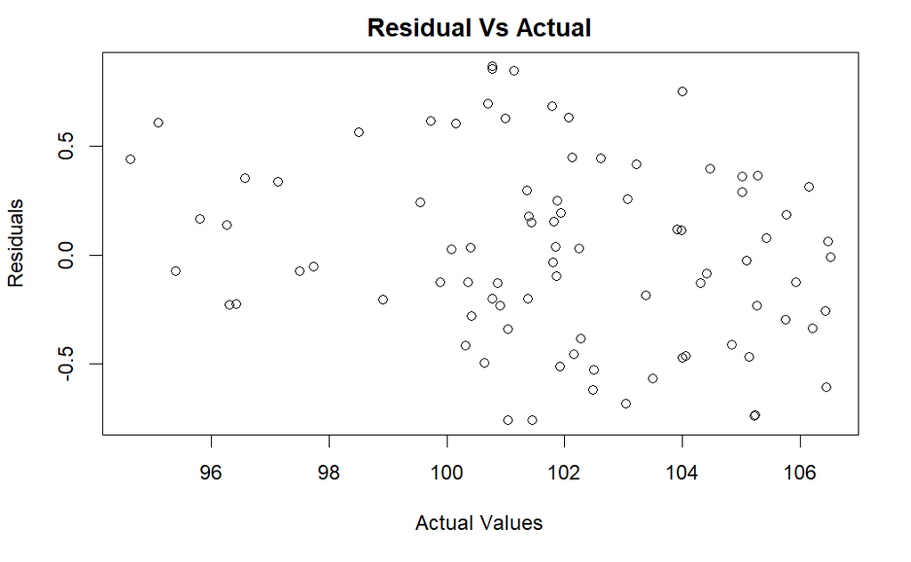

```r
plot(forecast_ma6$x,forecast_ma6$residuals,xy.labels=FALSE,xy.lines = FALSE,xlab="Actual Values",ylab="Residuals", main="Residual Vs Actual")
```

Residual Vs Fitted

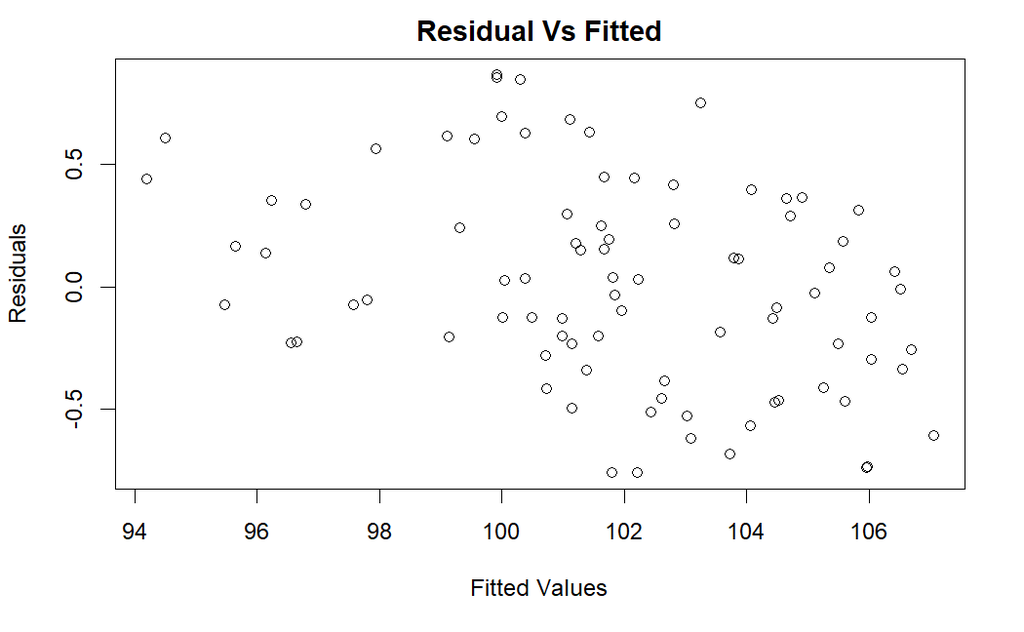

```r
plot(forecast_ma6$fitted,forecast_ma6$residuals,xy.labels=FALSE,xy.lines = FALSE,xlab="Fitted Values",ylab="Residuals", main="Residual Vs Fitted")
```

#### Accuracy Measures for Moving Averages

Let us take a look at the order 6 moving average model to see the accuracy measures.

```r
a_ma <- accuracy(forecast_ma6)
a_ma
```

```
                     ME      RMSE      MAE        MPE      MAPE      MASE      ACF1
Training set 0.01095049 0.4166802 0.344412 0.01351231 0.3381337 0.1193141 0.2099042
```

RMSE value for Order 6 moving averages model seems to be the best one so far but since the ACF od residuals was not satisfactory, we shall move on.

### ARIMA

Typically used for short range predictions due to its flexibility, we shall now try to do a forecast using ARIMA.

First, we need to make our data stationary

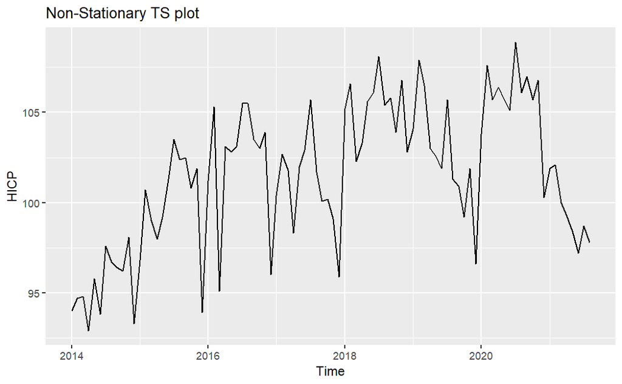

```r
autoplot(hicp_ts_recent,main="Non-Stationary TS plot",ylab="HICP")
```

```r
adf.test(hicp_ts_recent,k=12)
```

```
    Augmented Dickey-Fuller Test

data:  hicp_ts_recent
Dickey-Fuller = -2.0178, Lag order = 12, p-value = 0.5689
alternative hypothesis: stationary
```

Lets see how it looks after first round of differences

```r
ndiffs(hicp_ts_recent)
```

[output not shown]

We now know that the d part in ARIMA(p,d,q) is 1.

```r
ndiffs(hicp_ts_recent)
```

```
[1] 1
```

```r
nsdiffs(hicp_ts_recent) ##seasonal difference
```

```
[1] 0
```

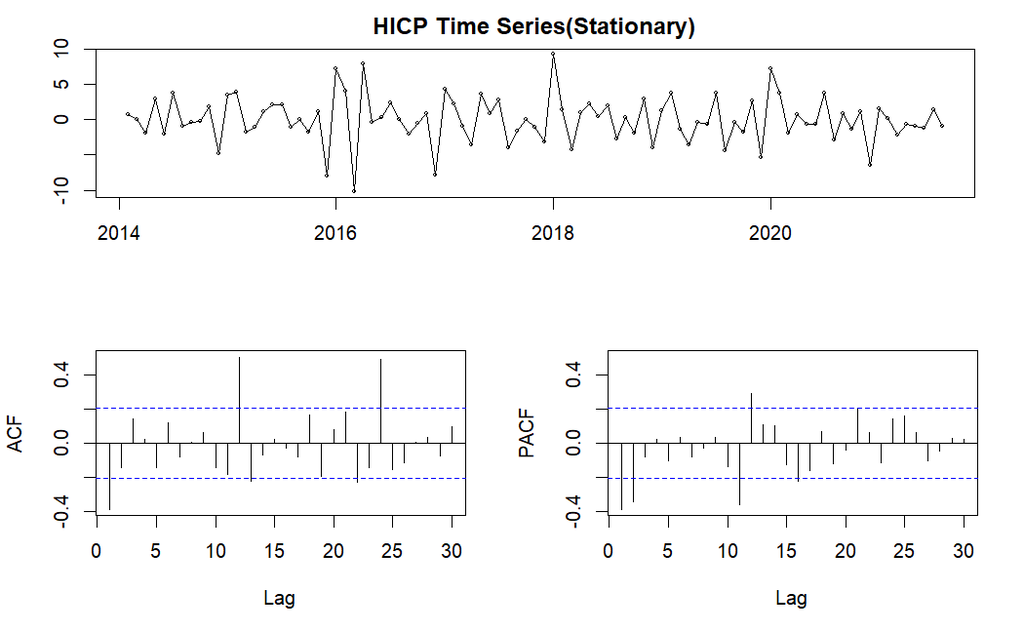

```r
hicp_d1 <- diff(hicp_ts_recent,differences=1)

tsdisplay(hicp_d1, main="HICP Time Series(Stationary)")
```

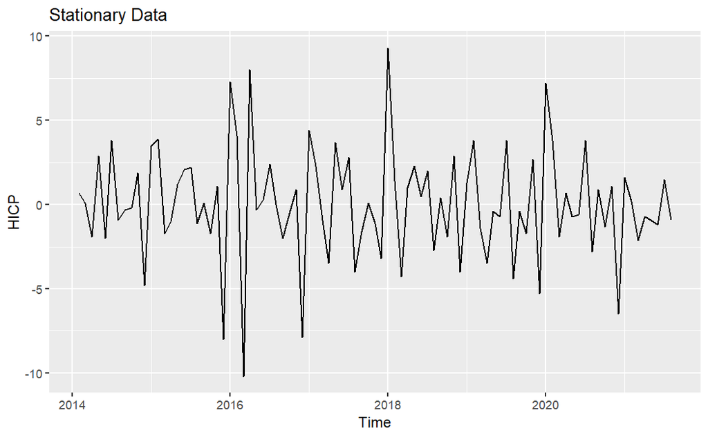

```r
autoplot(hicp_d1,main="Stationary Data",ylab="HICP")
```

Fitting the best ARIMA model

```r
auto_fit <- auto.arima(hicp_ts_recent,trace=TRUE,stepwise=FALSE,approximation=FALSE)
```

```
 ARIMA(0,1,0)                               : 476.569
 ARIMA(0,1,0)            with drift         : 478.6457
 ARIMA(0,1,0)(0,0,1)[12]                    : 463.9872
 ARIMA(0,1,0)(0,0,1)[12] with drift         : 466.1259
 ARIMA(0,1,0)(0,0,2)[12]                    : 446.6811
 ARIMA(0,1,0)(0,0,2)[12] with drift         : 448.8688
 ARIMA(0,1,0)(1,0,0)[12]                    : 451.0133
 ARIMA(0,1,0)(1,0,0)[12] with drift         : 453.1518
 ARIMA(0,1,0)(1,0,1)[12]                    : Inf
 ARIMA(0,1,0)(1,0,1)[12] with drift         : Inf
 ARIMA(0,1,0)(1,0,2)[12]                    : Inf
 ARIMA(0,1,0)(1,0,2)[12] with drift         : Inf
 ARIMA(0,1,0)(2,0,0)[12]                    : 435.127
 ARIMA(0,1,0)(2,0,0)[12] with drift         : 437.3153
 ARIMA(0,1,0)(2,0,1)[12]                    : Inf
 ARIMA(0,1,0)(2,0,1)[12] with drift         : Inf
 ARIMA(0,1,0)(2,0,2)[12]                    : Inf
 ARIMA(0,1,0)(2,0,2)[12] with drift         : Inf
 ARIMA(0,1,1)                               : 454.8355
 ARIMA(0,1,1)            with drift         : 456.8656
 ARIMA(0,1,1)(0,0,1)[12]                    : 446.2264
 ARIMA(0,1,1)(0,0,1)[12] with drift         : 448.4009
 ARIMA(0,1,1)(0,0,2)[12]                    : 423.6965
 ARIMA(0,1,1)(0,0,2)[12] with drift         : 425.9206
 ARIMA(0,1,1)(1,0,0)[12]                    : 435.3201
 ARIMA(0,1,1)(1,0,0)[12] with drift         : 437.5092
 ARIMA(0,1,1)(1,0,1)[12]                    : Inf
 ARIMA(0,1,1)(1,0,1)[12] with drift         : Inf
 ARIMA(0,1,1)(1,0,2)[12]                    : Inf
 ARIMA(0,1,1)(1,0,2)[12] with drift         : Inf
 ARIMA(0,1,1)(2,0,0)[12]                    : 415.8874
 ARIMA(0,1,1)(2,0,0)[12] with drift         : 418.1209
 ARIMA(0,1,1)(2,0,1)[12]                    : Inf
 ARIMA(0,1,1)(2,0,1)[12] with drift         : Inf
 ARIMA(0,1,1)(2,0,2)[12]                    : Inf
 ARIMA(0,1,1)(2,0,2)[12] with drift         : Inf
 ARIMA(0,1,2)                               : 456.8495
 ARIMA(0,1,2)            with drift         : 458.9126
 ARIMA(0,1,2)(0,0,1)[12]                    : 448.4046
 ARIMA(0,1,2)(0,0,1)[12] with drift         : 450.6315
```

[output cut: 141 more lines]

```
 ARIMA(3,1,2)            with drift         : Inf
 ARIMA(4,1,0)                               : 459.5093
 ARIMA(4,1,0)            with drift         : 461.7347
 ARIMA(4,1,0)(0,0,1)[12]                    : 448.8633
 ARIMA(4,1,0)(0,0,1)[12] with drift         : 451.2086
 ARIMA(4,1,0)(1,0,0)[12]                    : 436.2931
 ARIMA(4,1,0)(1,0,0)[12] with drift         : 438.6397
 ARIMA(4,1,1)                               : 460.7692
 ARIMA(4,1,1)            with drift         : Inf
 ARIMA(5,1,0)                               : 460.9504
 ARIMA(5,1,0)            with drift         : 463.2092



 Best model: ARIMA(0,1,1)(2,0,0)[12]
```

```r
auto_fit
```

```
Series: hicp_ts_recent
ARIMA(0,1,1)(2,0,0)[12]

Coefficients:
          ma1    sar1    sar2
      -0.4680  0.2310  0.5053
s.e.   0.0861  0.0841  0.0938

sigma^2 estimated as 4.759:  log likelihood=-203.71
AIC=415.42   AICc=415.89   BIC=425.47
```

#### Forecasting Using ARIMA

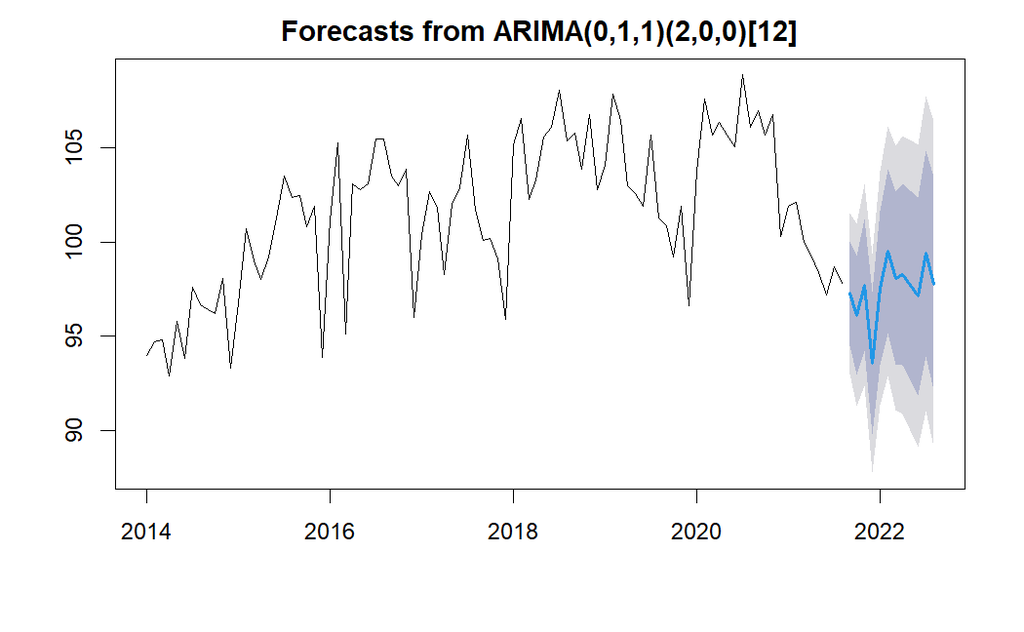

```r
arima_hicp <- forecast(auto_fit, h=12)
plot(arima_hicp)
```

```r
arima_hicp$mean
```

```
          Jan      Feb      Mar      Apr      May      Jun      Jul      Aug      Sep
2021                                                                         97.27438
2022 97.56136 99.52755 98.08239 98.27435 97.71274 97.13235 99.39888 97.77623
          Oct      Nov      Dec
2021 96.11509 97.73343 93.55385
2022
```

ARIMA model shows that for non-seasonal data requires 1 difference (as d=1) to make the data stationary and moving averages MA(1) as q value is 1. For the seasonal portion of the data, D=0 so there will be no differences required and it would need Auto Regression AR(1) and AR(2) as P=2 for seasonal portion. It also shows that there is a significant lag at 12.

#### Residual Analysis of ARIMA

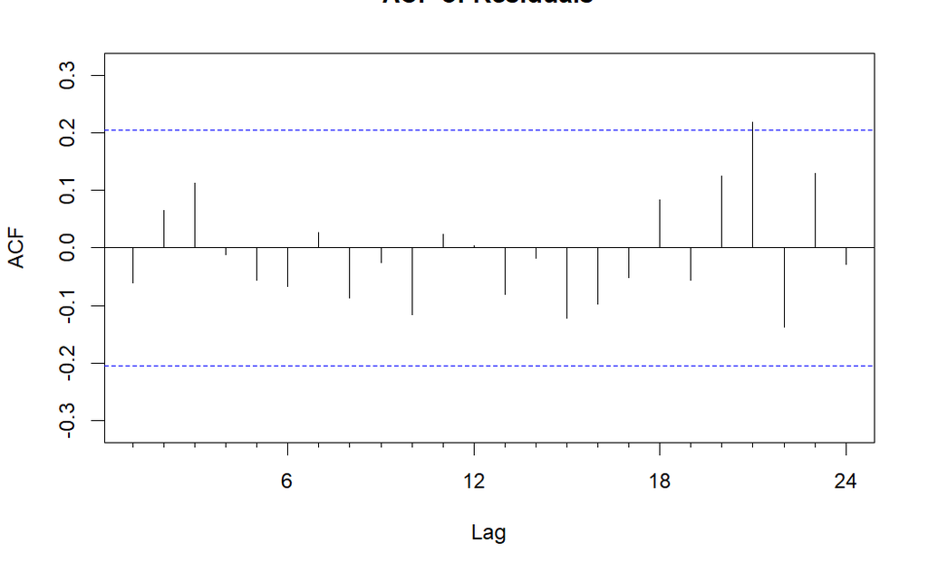

```r
Acf(auto_fit$residuals,main="ACF of Residuals")
```

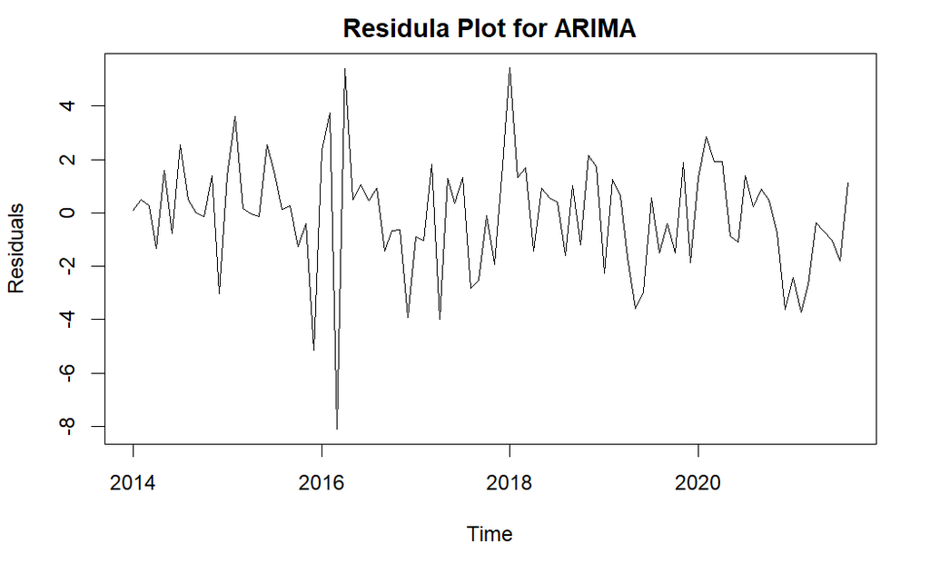

```r
plot.ts(residuals(auto_fit),ylab="Residuals",main="Residula Plot for ARIMA")
```

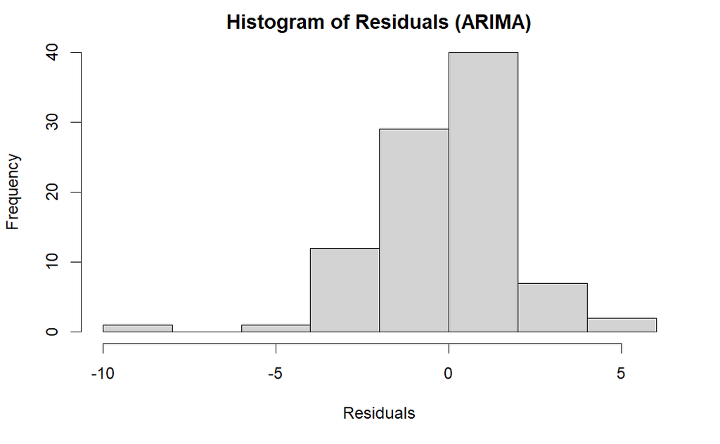

```r
hist(auto_fit$residuals, main="Histogram of Residuals (ARIMA)",xlab="Residuals")
```

#### Accuracy Measures

```r
a_arma <- accuracy(arima_hicp)
a_arma
```

```
                     ME     RMSE      MAE        MPE     MAPE      MASE        ACF1
Training set -0.1087859 2.133462 1.615173 -0.1367518 1.599689 0.4180325 -0.06022904
```

### Conclusion

- In conclusion, we can see that Moving Averages give the best RMSE measures. But at the same time the ACF of residuals for Moving Averages was not satisfactory. But looking at Holt-Winters and ARIMA, we can see that RMSE measures as well as ACF of residuals are both satisfactory. So we should go with one of these models or a combination of both for this particular prediction.
- Going back to the FRED website we could see that HICP for September and October has been updated : 97.6 for September and 96.2 for October. If we look at ARIMA model, we can see that it has made a pretty spot on prediction for Sept 2021 and Oct 2021. This means the ARIMA model is very much reliable.